# Stores

Kevien Otieno

2024-02-17

```r
#loading packages
pacman::p_load(tidyverse, tidyr, dplyr, ggplot2,lubridate)
```

```r
#loading our dataset
Stores=read.csv("Global Superstore.csv")
```

```r
#Lets View first 5 rows of our dataset
head(Stores, 5)
```

```
##   Row.ID        Order.ID Order.Date  Ship.Date    Ship.Mode Customer.ID
## 1  32298  CA-2012-124891 31-07-2012 31-07-2012     Same Day    RH-19495
## 2  26341   IN-2013-77878   5/2/2013   7/2/2013 Second Class    JR-16210
## 3  25330   IN-2013-71249 17-10-2013 18-10-2013  First Class    CR-12730
## 4  13524 ES-2013-1579342 28-01-2013 30-01-2013  First Class    KM-16375
## 5  47221    SG-2013-4320  5/11/2013  6/11/2013     Same Day     RH-9495
##      Customer.Name     Segment          City           State       Country
## 1      Rick Hansen    Consumer New York City        New York United States
## 2    Justin Ritter   Corporate    Wollongong New South Wales     Australia
## 3     Craig Reiter    Consumer      Brisbane      Queensland     Australia
## 4 Katherine Murray Home Office        Berlin          Berlin       Germany
## 5      Rick Hansen    Consumer         Dakar           Dakar       Senegal
##   Postal.Code Market  Region       Product.ID   Category Sub.Category
## 1       10024     US    East  TEC-AC-10003033 Technology  Accessories
## 2          NA   APAC Oceania  FUR-CH-10003950  Furniture       Chairs
## 3          NA   APAC Oceania  TEC-PH-10004664 Technology       Phones
## 4          NA     EU Central  TEC-PH-10004583 Technology       Phones
## 5          NA Africa  Africa TEC-SHA-10000501 Technology      Copiers
##                                                         Product.Name    Sales
## 1 Plantronics CS510 - Over-the-Head monaural Wireless Headset System 2309.650
## 2                          Novimex Executive Leather Armchair, Black 3709.395
## 3                                  Nokia Smart Phone, with Caller ID 5175.171
## 4                                     Motorola Smart Phone, Cordless 2892.510
## 5                                     Sharp Wireless Fax, High-Speed 2832.960
##   Quantity Discount    Profit Shipping.Cost Order.Priority
## 1        7      0.0  762.1845        933.57       Critical
## 2        9      0.1 -288.7650        923.63       Critical
## 3        9      0.1  919.9710        915.49         Medium
## 4        5      0.1  -96.5400        910.16         Medium
## 5        8      0.0  311.5200        903.04       Critical
```

```r
#lets check on the dimensions of our dataset
dim(Stores)
```

```
## [1] 51290    24
```

```r
#list all column names
names(Stores)
```

```
##  [1] "Row.ID"         "Order.ID"       "Order.Date"     "Ship.Date"
##  [5] "Ship.Mode"      "Customer.ID"    "Customer.Name"  "Segment"
##  [9] "City"           "State"          "Country"        "Postal.Code"
## [13] "Market"         "Region"         "Product.ID"     "Category"
## [17] "Sub.Category"   "Product.Name"   "Sales"          "Quantity"
## [21] "Discount"       "Profit"         "Shipping.Cost"  "Order.Priority"
```

```r
#lets check on the datatypes of our columns
str(Stores)
```

```
## 'data.frame':    51290 obs. of  24 variables:
##  $ Row.ID        : int  32298 26341 25330 13524 47221 22732 30570 31192 40155 40936 ...
##  $ Order.ID      : chr  "CA-2012-124891" "IN-2013-77878" "IN-2013-71249" "ES-2013-1579342" ...
##  $ Order.Date    : chr  "31-07-2012" "5/2/2013" "17-10-2013" "28-01-2013" ...
##  $ Ship.Date     : chr  "31-07-2012" "7/2/2013" "18-10-2013" "30-01-2013" ...
##  $ Ship.Mode     : chr  "Same Day" "Second Class" "First Class" "First Class" ...
##  $ Customer.ID   : chr  "RH-19495" "JR-16210" "CR-12730" "KM-16375" ...
##  $ Customer.Name : chr  "Rick Hansen" "Justin Ritter" "Craig Reiter" "Katherine Murray" ...
##  $ Segment       : chr  "Consumer" "Corporate" "Consumer" "Home Office" ...
##  $ City          : chr  "New York City" "Wollongong" "Brisbane" "Berlin" ...
##  $ State         : chr  "New York" "New South Wales" "Queensland" "Berlin" ...
##  $ Country       : chr  "United States" "Australia" "Australia" "Germany" ...
##  $ Postal.Code   : int  10024 NA NA NA NA NA NA NA 95823 28027 ...
##  $ Market        : chr  "US" "APAC" "APAC" "EU" ...
##  $ Region        : chr  "East" "Oceania" "Oceania" "Central" ...
##  $ Product.ID    : chr  "TEC-AC-10003033" "FUR-CH-10003950" "TEC-PH-10004664" "TEC-PH-10004583" ...
##  $ Category      : chr  "Technology" "Furniture" "Technology" "Technology" ...
##  $ Sub.Category  : chr  "Accessories" "Chairs" "Phones" "Phones" ...
##  $ Product.Name  : chr  "Plantronics CS510 - Over-the-Head monaural Wireless Headset System" "Novimex Executive Leather Armchair, Black" "Nokia Smart Phone, with Caller ID" "Motorola Smart Phone, Cordless" ...
##  $ Sales         : num  2310 3709 5175 2893 2833 ...
##  $ Quantity      : int  7 9 9 5 8 5 4 6 5 13 ...
##  $ Discount      : num  0 0.1 0.1 0.1 0 0.1 0 0 0.2 0.4 ...
##  $ Profit        : num  762.2 -288.8 920 -96.5 311.5 ...
##  $ Shipping.Cost : num  934 924 915 910 903 ...
##  $ Order.Priority: chr  "Critical" "Critical" "Medium" "Medium" ...
```

```r
#Separating the dates into other new columns i.e shipping day, month or year
Stores=Stores %>%
  separate(col="Order.Date",
           into=c("Order.Day", "Order.Month","Order.Year"),
           sep="[-/]", remove = FALSE)

Stores=Stores %>%
  separate(col="Ship.Date",
           into=c("Ship.Day","Ship.Month","Ship.Year"),
           sep="[-/]", remove = FALSE)
```

```r
#converting a few columns into the necessary wanted datatypes
Stores$Order.Day=as.integer(Stores$Order.Day)
Stores$Order.Month=as.integer(Stores$Order.Month)
Stores$Order.Year=as.integer(Stores$Order.Year)
Stores$Ship.Day=as.integer(Stores$Ship.Day)
Stores$Ship.Month=as.integer(Stores$Order.Month)
Stores$Ship.Year=as.integer(Stores$Ship.Year)
Stores$Ship.Mode=as.factor(Stores$Ship.Mode)
Stores$Category=as.factor(Stores$Category)
Stores$Order.Priority =as.factor(Stores$Order.Priority)
Stores$Ship.Month=as.character(Stores$Order.Month)
Stores$Order.Month=as.character(Stores$Order.Month)
```

```r
#renaming the months into the expected
Stores=Stores %>%
  mutate(
    Order.Month =case_when(Order.Month == 1 ~ "January",Order.Month == 2 ~ "February",
                         Order.Month == 3 ~ "March",Order.Month == 4 ~ "April",
                         Order.Month == 5 ~ "May",Order.Month == 6 ~ "June",
                         Order.Month == 7 ~ "July",Order.Month == 8 ~ "August",
                         Order.Month == 9 ~ "September",Order.Month == 10 ~ "October",
                         Order.Month == 11 ~ "November",Order.Month == 12 ~ "December"))

Stores=Stores %>%
  mutate(
    Ship.Month =case_when(Ship.Month == 1 ~ "January",Ship.Month == 2 ~ "February",
                         Ship.Month == 3 ~ "March",Ship.Month == 4 ~ "April",
                         Ship.Month == 5 ~ "May",Ship.Month == 6 ~ "June",
                         Ship.Month == 7 ~ "July",Ship.Month == 8 ~ "August",
                         Ship.Month == 9 ~ "September",Ship.Month == 10 ~ "October",
                         Ship.Month == 11 ~ "November",Ship.Month == 12 ~ "December"))
```

```r
#checking the datatypes again
str(Stores)
```

```
## 'data.frame':    51290 obs. of  30 variables:
##  $ Row.ID        : int  32298 26341 25330 13524 47221 22732 30570 31192 40155 40936 ...
##  $ Order.ID      : chr  "CA-2012-124891" "IN-2013-77878" "IN-2013-71249" "ES-2013-1579342" ...
##  $ Order.Date    : chr  "31-07-2012" "5/2/2013" "17-10-2013" "28-01-2013" ...
##  $ Order.Day     : int  31 5 17 28 5 28 7 14 14 28 ...
##  $ Order.Month   : chr  "July" "February" "October" "January" ...
##  $ Order.Year    : int  2012 2013 2013 2013 2013 2013 2011 2012 2014 2012 ...
##  $ Ship.Date     : chr  "31-07-2012" "7/2/2013" "18-10-2013" "30-01-2013" ...
##  $ Ship.Day      : int  31 7 18 30 6 1 9 18 21 31 ...
##  $ Ship.Month    : chr  "July" "February" "October" "January" ...
##  $ Ship.Year     : int  2012 2013 2013 2013 2013 2013 2011 2012 2014 2012 ...
##  $ Ship.Mode     : Factor w/ 4 levels "First Class",..: 2 3 1 1 2 3 1 4 4 3 ...
##  $ Customer.ID   : chr  "RH-19495" "JR-16210" "CR-12730" "KM-16375" ...
##  $ Customer.Name : chr  "Rick Hansen" "Justin Ritter" "Craig Reiter" "Katherine Murray" ...
##  $ Segment       : chr  "Consumer" "Corporate" "Consumer" "Home Office" ...
```

[output cut: 16 more lines]

Working on the date columns

```r
#lets now get the summary for our dataset
summary(Stores)
```

```
##      Row.ID        Order.ID          Order.Date          Order.Day
##  Min.   :    1   Length:51290       Length:51290       Min.   : 1.00
##  1st Qu.:12823   Class :character   Class :character   1st Qu.: 8.00
##  Median :25646   Mode  :character   Mode  :character   Median :16.00
##  Mean   :25646                                         Mean   :15.78
##  3rd Qu.:38468                                         3rd Qu.:23.00
##  Max.   :51290                                         Max.   :31.00
##
##  Order.Month          Order.Year    Ship.Date            Ship.Day
##  Length:51290       Min.   :2011   Length:51290       Min.   : 1.00
##  Class :character   1st Qu.:2012   Class :character   1st Qu.: 8.00
##  Mode  :character   Median :2013   Mode  :character   Median :16.00
##                     Mean   :2013                      Mean   :15.87
##                     3rd Qu.:2014                      3rd Qu.:23.00
##                     Max.   :2014                      Max.   :31.00
##
##   Ship.Month          Ship.Year             Ship.Mode     Customer.ID
##  Length:51290       Min.   :2011   First Class   : 7505   Length:51290
##  Class :character   1st Qu.:2012   Same Day      : 2701   Class :character
##  Mode  :character   Median :2013   Second Class  :10309   Mode  :character
##                     Mean   :2013   Standard Class:30775
##                     3rd Qu.:2014
##                     Max.   :2015
##
##  Customer.Name        Segment              City              State
##  Length:51290       Length:51290       Length:51290       Length:51290
##  Class :character   Class :character   Class :character   Class :character
##  Mode  :character   Mode  :character   Mode  :character   Mode  :character
##
##
##
##
##    Country           Postal.Code       Market             Region
##  Length:51290       Min.   : 1040   Length:51290       Length:51290
##  Class :character   1st Qu.:23223   Class :character   Class :character
##  Mode  :character   Median :56431   Mode  :character   Mode  :character
##                     Mean   :55190
##                     3rd Qu.:90008
##                     Max.   :99301
##                     NA's   :41296
```

[output cut: 9 more lines]

```
##  Length:51290       Min.   :    0.444   Min.   : 1.000   Min.   :0.0000
##  Class :character   1st Qu.:   30.759   1st Qu.: 2.000   1st Qu.:0.0000
##  Mode  :character   Median :   85.053   Median : 3.000   Median :0.0000
##                     Mean   :  246.491   Mean   : 3.477   Mean   :0.1429
##                     3rd Qu.:  251.053   3rd Qu.: 5.000   3rd Qu.:0.2000
##                     Max.   :22638.480   Max.   :14.000   Max.   :0.8500
##
##      Profit         Shipping.Cost     Order.Priority
##  Min.   :-6599.98   Min.   :  0.00   Critical: 3932
##  1st Qu.:    0.00   1st Qu.:  2.61   High    :15501
##  Median :    9.24   Median :  7.79   Low     : 2424
##  Mean   :   28.61   Mean   : 26.38   Medium  :29433
##  3rd Qu.:   36.81   3rd Qu.: 24.45
##  Max.   : 8399.98   Max.   :933.57
##
```

```
    Perform an Exploratory Data Analysis
```

Customers Analysis  
1.Profile the customers based on their frequency of purchase - calculate frequency of purchase for each customer

```r
freq_purch=Stores %>%
  select(Customer.ID, Customer.Name) %>%
  group_by(Customer.Name) %>%
  summarise(Frequency=n()) %>%
  arrange(Frequency, by_group = TRUE)

Most_frequent_customers=tail(freq_purch,5)
```

2.Do the high frequent customers are contributing more revenue

```r
Stores %>%
  select(Customer.ID, Customer.Name, Sales) %>%
  group_by(Customer.Name) %>%
  summarise(Total_sales=sum(Sales),Frequency=n()) %>%
  arrange(desc(Total_sales),desc(Frequency)) %>%
  head(5)
```

```
## # A tibble: 5 × 3
##   Customer.Name      Total_sales Frequency
##   <chr>                    <dbl>     <int>
## 1 Tom Ashbrook            40488.        80
## 2 Tamara Chand            37457.        88
## 3 Greg Tran               35551.        87
## 4 Christopher Conant      35187.        73
## 5 Sean Miller             35171.        50
```

3.Are they also profitable - what is the profit margin across the buckets

```r
Stores %>%
  select(Customer.ID, Customer.Name, Profit) %>%
  group_by(Customer.Name) %>%
  summarise(Total_Profits=sum(Profit),Frequency=n()) %>%
  arrange(desc(Total_Profits),desc(Frequency)) %>%
  head(5)
```

```
## # A tibble: 5 × 3
##   Customer.Name Total_Profits Frequency
##   <chr>                 <dbl>     <int>
## 1 Tamara Chand          8673.        88
## 2 Raymond Buch          8453.        71
## 3 Sanjit Chand          8205.        69
## 4 Hunter Lopez          7817.        53
## 5 Bill Eplett           7410.       102
```

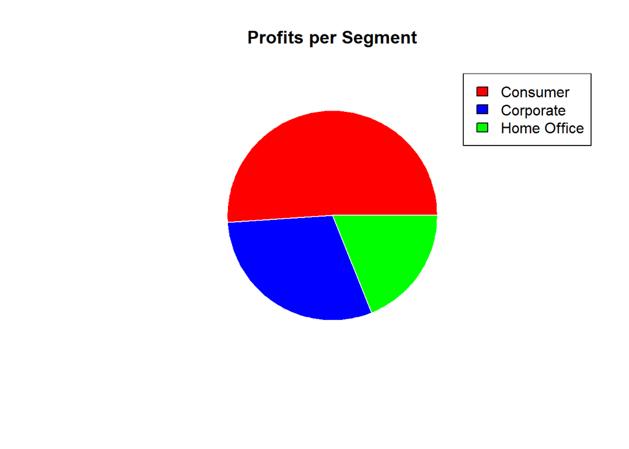

```r
segment_customer= Stores %>%
  select(Segment, Profit) %>%
  group_by(Segment) %>%
  summarise(Total_Profits=ceiling(sum(Profit))) %>%
  arrange(desc(Total_Profits))

pie(segment_customer$Total_Profits,
    labels =NA,
    lwd=2,
    main = "Profits per Segment",
    border="white",
    col = c("red","blue","green",
    cex.main =1.5
    ))

legend("topright", legend=segment_customer$Segment,fill = c("red","blue","green", title = "Segments"))
```

```r
dist_Country=Stores %>%
  select(Country) %>%
  group_by(Country) %>%
  summarise(Frequency=n())
```

Product Analysis  
1.Which country has top sales?

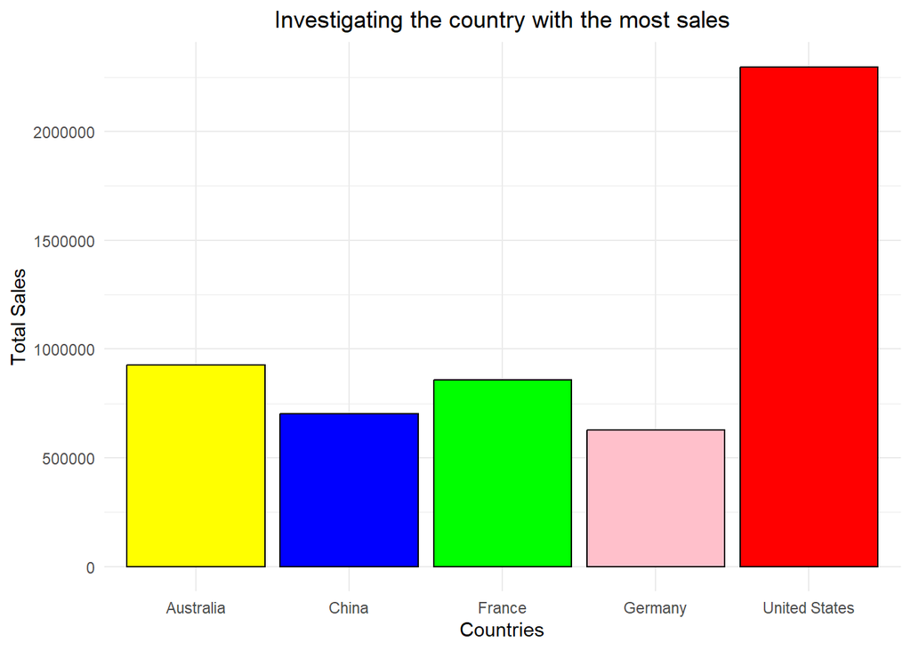

```r
c_top=Stores %>%
  select(Country, Sales) %>%
  group_by(Country) %>%
  summarise(Total_Sales=sum(Sales)) %>%
  arrange(desc(Total_Sales)) %>%
  head(5)

ggplot(c_top, aes(x=Country, y=Total_Sales))+
  geom_bar(stat="identity",col="black",fill=c("red","yellow","green","blue","pink"))+
  labs(title = "Investigating the country with the most sales", x="Countries",y="Total Sales")+
  theme_minimal()+
  scale_fill_manual()+
  theme(plot.title = element_text(hjust=0.5))
```

2.Which are the top 5 profit-making product types on a yearly basis?

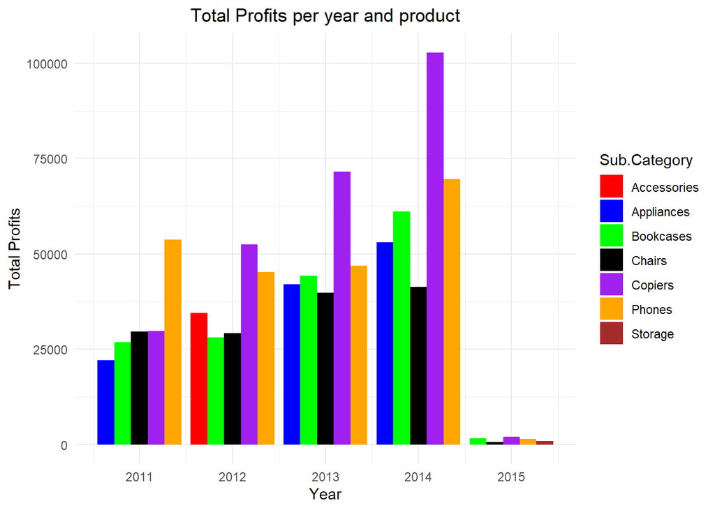

```r
profit_product <-
  rbind(
  (Stores %>%
  select(Ship.Year, Sub.Category, Profit) %>%
  filter(Ship.Year == 2011) %>%
  group_by(Ship.Year,Sub.Category) %>%
  summarise(Total_profits = ceiling(sum(Profit)), .groups = 'drop') %>%
  arrange(desc(Total_profits)) %>%
  head(5)),
  (Stores %>%
  select(Ship.Year, Sub.Category, Profit) %>%
  filter(Ship.Year == 2012) %>%
  group_by(Ship.Year,Sub.Category) %>%
  summarise(Total_profits = ceiling(sum(Profit)), .groups = 'drop') %>%
  arrange(desc(Total_profits)) %>%
  head(5)),
  (Stores %>%
  select(Ship.Year, Sub.Category, Profit) %>%
  filter(Ship.Year == 2013) %>%
  group_by(Ship.Year,Sub.Category) %>%
  summarise(Total_profits = ceiling(sum(Profit)), .groups = 'drop') %>%
  arrange(desc(Total_profits)) %>%
  head(5)),
  (Stores %>%
  select(Ship.Year, Sub.Category, Profit) %>%
  filter(Ship.Year == 2014) %>%
  group_by(Ship.Year,Sub.Category) %>%
  summarise(Total_profits = ceiling(sum(Profit)), .groups = 'drop') %>%
  arrange(desc(Total_profits)) %>%
  head(5)),
  (Stores %>%
  select(Ship.Year, Sub.Category, Profit) %>%
  filter(Ship.Year == 2015) %>%
  group_by(Ship.Year,Sub.Category) %>%
  summarise(Total_profits = ceiling(sum(Profit)), .groups = 'drop') %>%
  arrange(desc(Total_profits)) %>%
  head(5)))

ggplot(profit_product, aes(x=Ship.Year, y=Total_profits, fill=Sub.Category))+
  geom_bar(stat = "identity", position = "dodge")+
  labs(title = "Total Profits per year and product", x= "Year", y= "Total Profits")+
  theme_minimal()+
  theme(plot.title = element_text(hjust = 0.5))+
  scale_fill_manual(values = c("red","blue","green","black","purple","orange","brown"))
```

5.What is the profit by month? (Use a line chart to visualize this.)

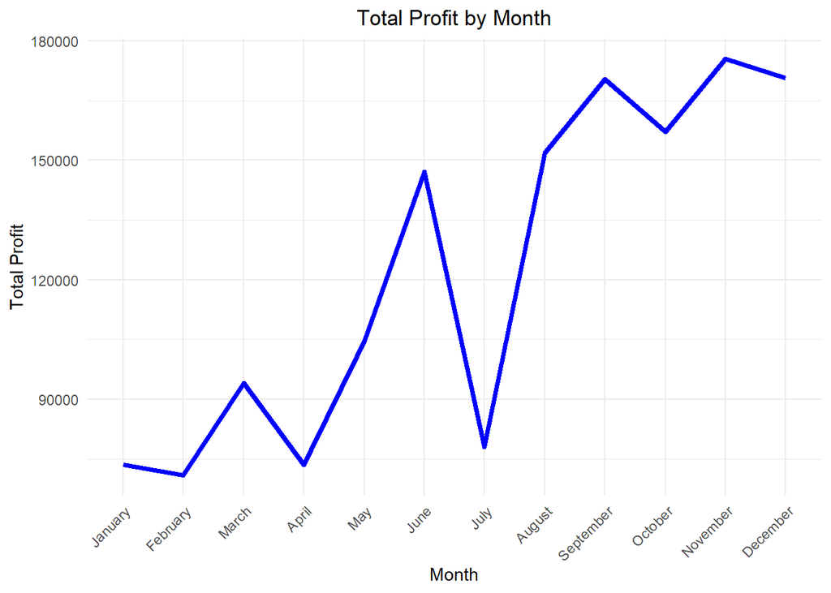

```r
profit_month=Stores %>%
  select(Order.Month, Profit) %>%
  group_by(Order.Month) %>%
  summarise(Total_Profits=ceiling(sum(Profit)))

profit_month$Order.Month <- factor(profit_month$Order.Month, levels = month.name)

ggplot(profit_month, aes(x = Order.Month, y = Total_Profits, group=1)) +
  geom_line(color = "blue", linewidth = 1.5) +
  labs(title = "Total Profit by Month", x = "Month", y = "Total Profit") +
  theme_minimal() +
  theme(
    plot.title = element_text(hjust = 0.5),
    axis.text.x = element_text(angle = 45, hjust = 1)
  )
```

6.Profit by category? By Subcategory?

```r
profit_category=Stores %>%
  select(Category, Profit) %>%
  group_by(Category) %>%
  summarise(Total_Profits=ceiling(sum(Profit)))

profit_subcategory=Stores %>%
  select(Sub.Category, Profit) %>%
  group_by(Sub.Category) %>%
  summarise(Total_Profits=ceiling(sum(Profit)))

print(profit_subcategory)
```

```
## # A tibble: 17 × 2
##    Sub.Category Total_Profits
##    <chr>                <dbl>
##  1 Accessories         129627
##  2 Appliances          141681
##  3 Art                  57954
##  4 Binders              72450
##  5 Bookcases           161925
##  6 Chairs              140397
##  7 Copiers             258568
##  8 Envelopes            29602
##  9 Fasteners            11526
## 10 Furnishings          46968
## 11 Labels               15011
## 12 Machines             58868
## 13 Paper                59208
## 14 Phones              216718
## 15 Storage             108462
## 16 Supplies             22584
## 17 Tables              -64083
```

[figure not shown]

```r
pie(profit_category$Total_Profits,
    labels = profit_category$Category,
    lwd=2,
    main="Profits per Category",
    col=c("red", "blue","pink"),
    border = "white",  # Add white border around each slice
  lwd = 2,  # Increase line width for slice outlines
  clockwise = TRUE,  # Change the direction of the slices to clockwise
  init.angle = 90,  # Start drawing slices from the top (90 degrees)
  cex.main = 1.5,  # Increase the size of the main title
  cex.lab = 1.2,   # Increase the size of the labels
  cex.axis = 0.8   # Adjust the size of the axis text
  )

legend("topright", legend=profit_category$Category, fill=c("red","blue","green"), title="Categories")
```

7.Sales by month? By category? By subcategory?

```r
sales_month=Stores %>%
  select(Order.Month, Sales) %>%
  group_by(Order.Month) %>%
  summarise(Total_Sales=ceiling(sum(Sales)))

sales_month$Order.Month <- factor(sales_month$Order.Month, levels = month.name)

sales_category=Stores %>%
  select(Category, Sales) %>%
  group_by(Category) %>%
  summarise(Total_Sales=ceiling(sum(Sales)))

sales_subcategory=Stores %>%
  select(Sub.Category, Sales) %>%
  group_by(Sub.Category) %>%
  summarise(Total_Sales=ceiling(sum(Sales)))

print(sales_subcategory)
```

```
## # A tibble: 17 × 2
##    Sub.Category Total_Sales
##    <chr>              <dbl>
##  1 Accessories       749238
##  2 Appliances       1011065
##  3 Art               372092
##  4 Binders           461912
##  5 Bookcases        1466573
##  6 Chairs           1501682
##  7 Copiers          1509437
##  8 Envelopes         170905
##  9 Fasteners          83243
## 10 Furnishings       385579
## 11 Labels             73405
## 12 Machines          779061
## 13 Paper             244292
## 14 Phones           1706825
## 15 Storage          1127086
## 16 Supplies          243075
## 17 Tables            757042
```

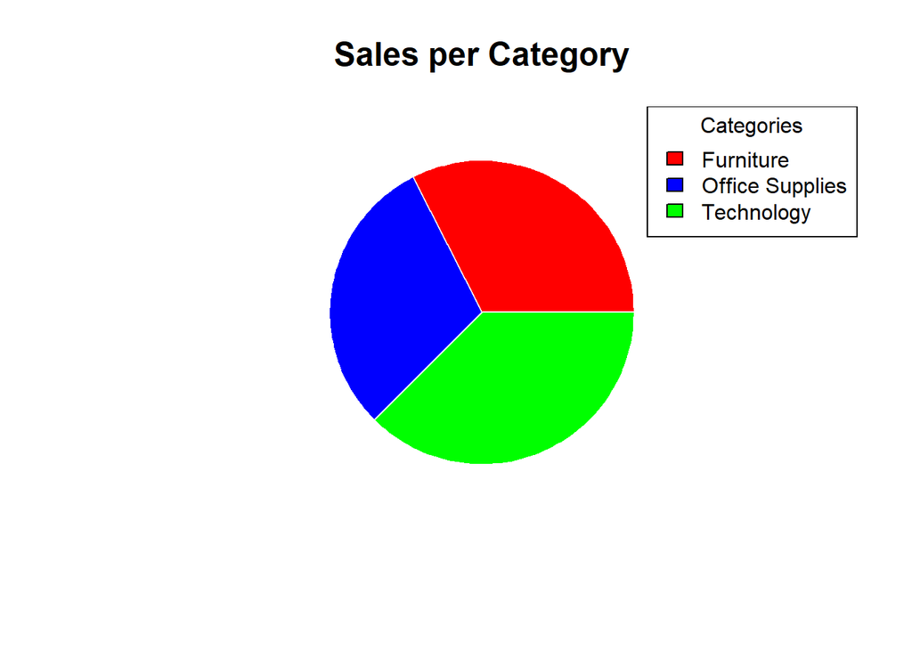

```r
pie(sales_category$Total_Sales,
    labels = NA,
    lwd=2,
    main="Sales per Category",
    col=c("red","blue","green"),
    border = "white",
    cex.main=1.5
    )

legend("topright", legend = sales_category$Category, fill = c("red","blue","green"), title = "Categories")
```

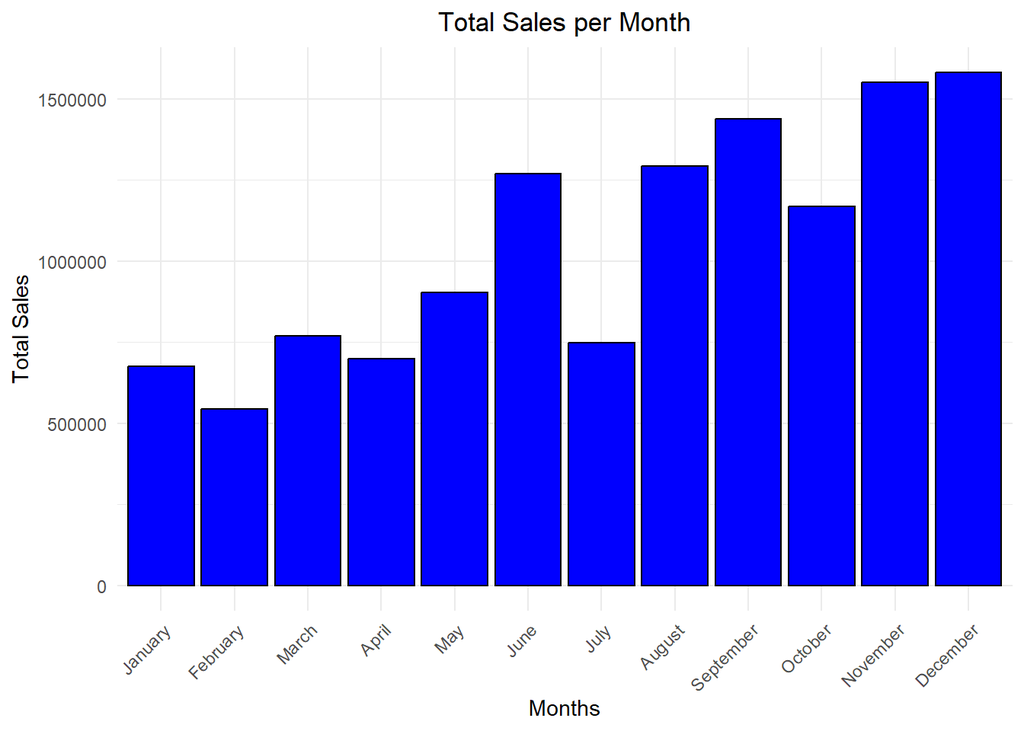

```r
ggplot(sales_month, aes(x=Order.Month, y= Total_Sales))+
  geom_bar(stat="identity", col="black", fill="blue")+
  labs(title = "Total Sales per Month", x= "Months", y="Total Sales")+
  theme_minimal()+
  theme(
    plot.title = element_text(hjust=0.5),
    axis.text.x = element_text(angle = 45, hjust=1)
  )
```